# Thinkful - Final Capstone: Siting Wind Farms

## Datasets and Unsupervised Learning model

### Jeremy Brezovan, December 2019

## What is the problem you are attempting to solve?

**For this capstone, I would like to build a model to determine strong candidate sites for new wind farms.**

## How is your solution valuable?

**Renewable energy, including wind, is a growing business.** [This wind energy factsheet from the University of Michigan](http://css.umich.edu/factsheets/wind-energy-factsheet) contains a lot of great information, including the following graph, which shows the steady increase in windpower capacity in the US since the year 2001:

[figure not shown]

**A model like the one I propose could be useful to multiple stakeholders in potential wind energy projects:**

- Investors looking for optimal locations for new wind farms, who can more easily identify and prioritize potential sites;
- Turbine manufacturers interested in submitting proposals for projects could use this model to help them determine which of their products would be more suitable (in terms of height and output capacity, for instance);
- The general public, by quantifying and illustrating the reasons why particular sites are favored over others. The placement of wind farms has been an occasionally contentious issue, particularly for residents who live in proximity to a selected site, or who have concerns about turbines’ effects on local wildlife.

With additional work, this model could serve as the core of a tool where a user could enter the GPS coordinates of a point or area, and receive up-to-date information about that site’s viability.

## What is your data source and how will you access it?

At least four major factors come into play when siting a wind project, according to the [American Wind Energy Association](https://www.awea.org/wind-101/siting-a-project).

1. **Strong and consistent winds.**
2. **Large, open space, such as agricultural land.**
3. **Minimal risk to wildlife.**
4. **Community acceptance.**

**Additional factors could include:**

- **Proximity to transmission lines that can carry the generated power to customers**
- **Placement to minimize “shadow flicker”**, the repetitive shadow cast on nearby homes and business by rotating blades, usually during sunrise and sunset.

## Input data

I searched for datasets representing as many of AWEA's factors for siting turbines as I could find, hoping to cover all of the major factors. Here are the four I ended up using for this project:

1. US state and national borders.
2. Existing turbines in the US.
3. Existing power lines in the US.
4. NREL wind data. Locations are ranked by class, 1-7. Topography is factored into the calculation of class.

Let's explore these datasets individually, then combine features so we can train models to predict good locations for new turbines.

### 1. US state and national borders

Found a shapefile of US borders on [data.gov](https://catalog.data.gov/dataset/tiger-line-shapefile-2017-nation-u-s-current-state-and-equivalent-national)--this will serve as the base of most of the static maps.

This dataset has some other interesting features, like the area of land and water for a given state, but for our purposes only the 'geometry' feature, representing each state's borders, is relevant.

To make things somewhat simpler, let's focus on the 48 contiguous states (so, skip Alaska and Hawaii).

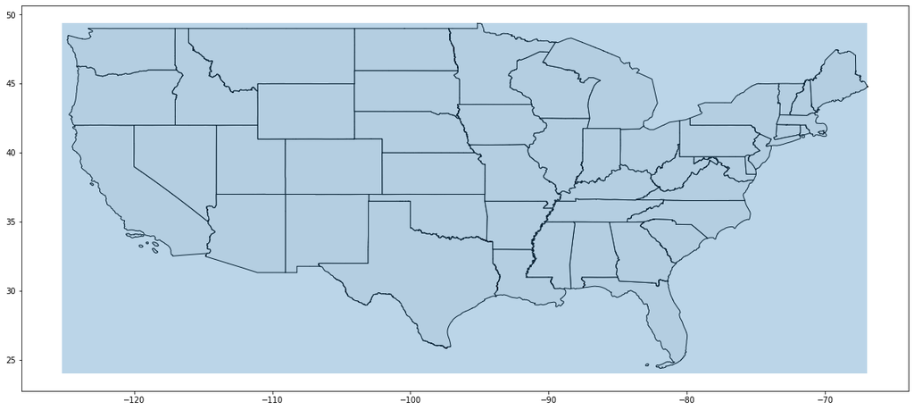

```python
border_map(lower48_borders,latlong_limits)
```

## 2. Locations of existing turbines in the US

Shapefile obtained via the [US Wind Turbine Database](https://www.sciencebase.gov/catalog/item/57bdfd8fe4b03fd6b7df5ff9).

Besides location, this dataset contains information about each turbine (manufacturer, model, power capacity). Metadata is available via a .csv on the site--look for a link to a file named "EntityandAttribute_DataDictionary.csv".

**We can provide these variables to an unsupervised learning model** to classify turbines.

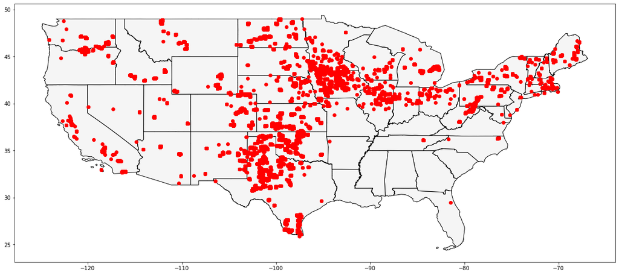

```python
ax = lower48_borders.plot(figsize=(20,20),color='whitesmoke',edgecolor='black')
existing_lower48.plot(figsize=(15,15),ax=ax,color='red')
plt.show()
plt.close()
```

## 3. Existing transmission lines in the US

Transmission lines will be needed to carry turbine-generated power to customers, from potentially remote areas where wind farms are located. The locations of suitable lines are in this shapefile, retrieved from the [Homeland Infrastructure Foundation website](https://hifld-geoplatform.opendata.arcgis.com/datasets/electric-power-transmission-lines).

- Identify high-voltage transmission lines--these are better-suited for conveying the power generated by a wind farm to customers.
- For now, we only care about lines that already exist, and lines under construction. We may choose to include proposed lines later, but given a lower weight for the model.

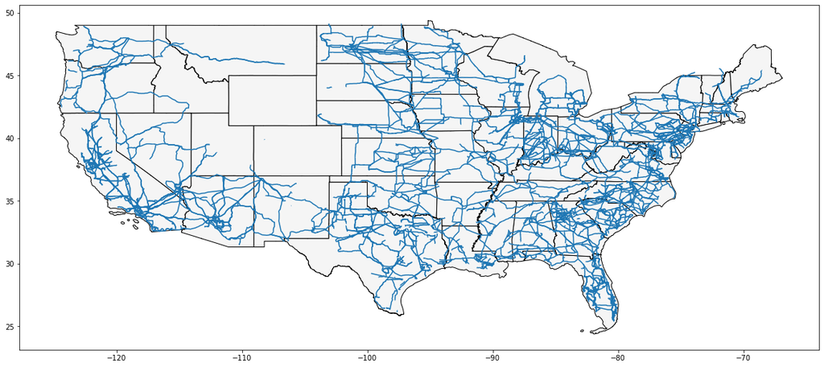

```python
ax = lower48_borders.plot(figsize=(20,20),color='whitesmoke',edgecolor='black')
high_power_lines.plot(figsize=(15,15),ax=ax)
plt.show()
plt.close()
```

## 4. NREL wind / basic topography classification

I chose two datasets from [the Wind Data page of NREL's Geospatial Data Science site](https://www.nrel.gov/gis/data-wind.html). (NREL is the National Renewable Energy Laboratory.)

Mean wind speeds, as well as basic topography, determine the "wind power class" to which an area belongs.

- One dataset is labeled "no exclusions" and is purely based on consistent wind speed and topography;
- The other dataset is labeled "with exclusions"--exclusions include urban areas, parks and preserves, and land otherwise not suited to a wind farm. These areas are excluded entirely from the data.

[figure not shown]

This map shows a sample of the NREL dataset with exclusions, shaded by wind_class. Existing turbines are shown in red.

## Use clustering to create a turbine_class feature for our supervised learning model

The first task is to generate a turbine_class feature, describing the type of turbines best suited to a given area.

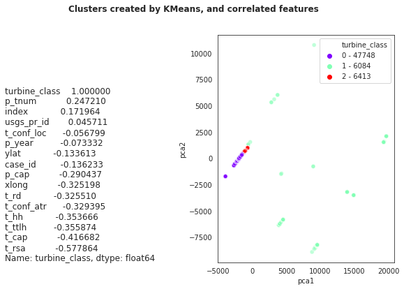

```python
km_clust_pca = model_comparison(km,
                                existing_lower48,
                                unsup_turbines.drop('t_manu_model',axis='columns'),
                                km_turbine_class)
```

### Here's how the turbine classes look.

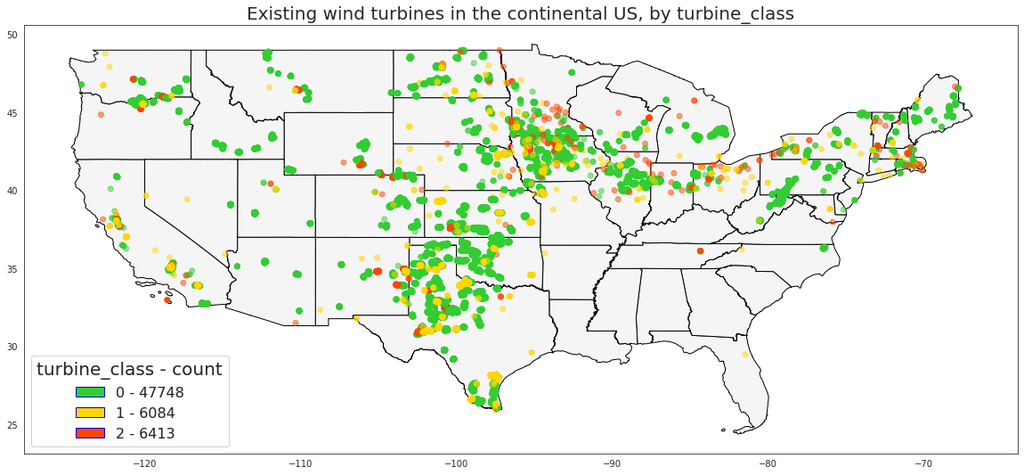

```python
turbine_class_color_map(existing_lower48,lower48_borders)
```

### What differentiates the turbine classes?

At a glance--**Class 1 is where the turbines with unknown attributes (-9999) landed.**

The other classes have some unknown values for usgs_pr_id, but values for all of the other attributes (height, capacity, turbine radius, etc.) are known.

Here are histograms of each feature fed to the unsupervised learning model, broken down by turbine_class. Let's use these plots to further analyze the types of turbines in each category:

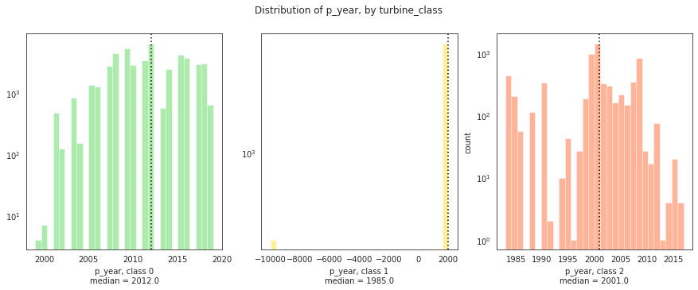

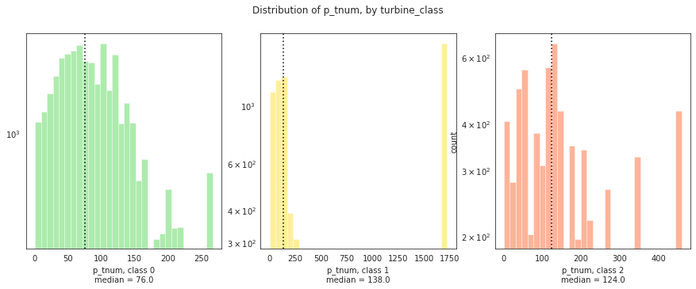

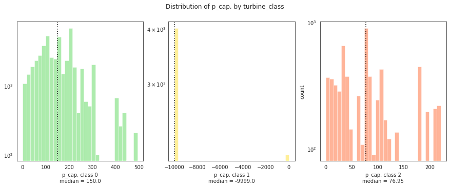

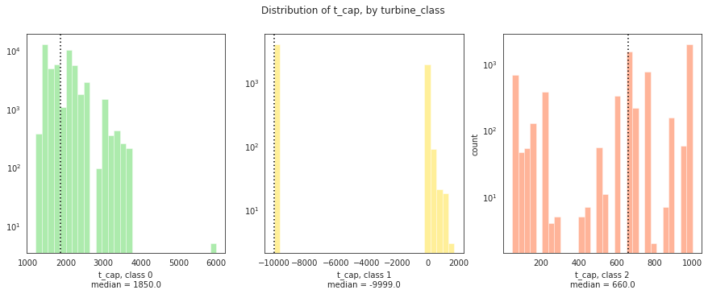

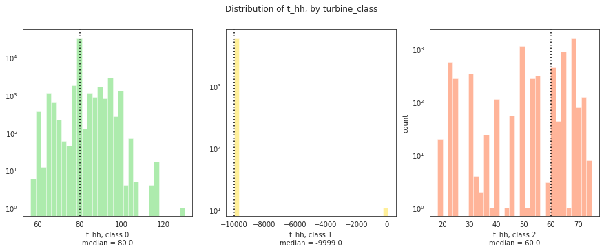

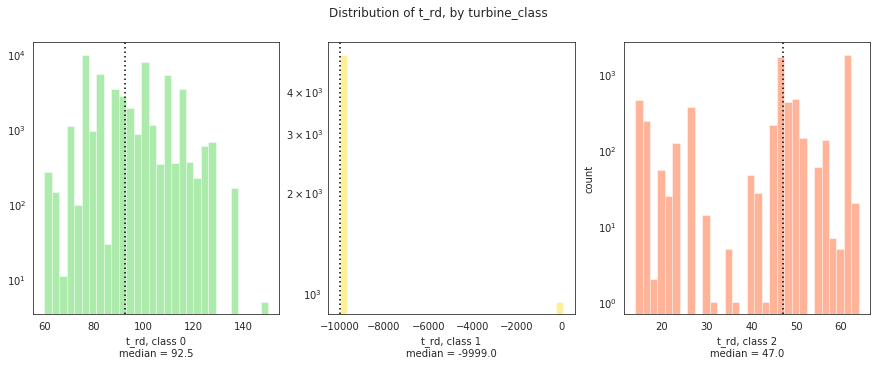

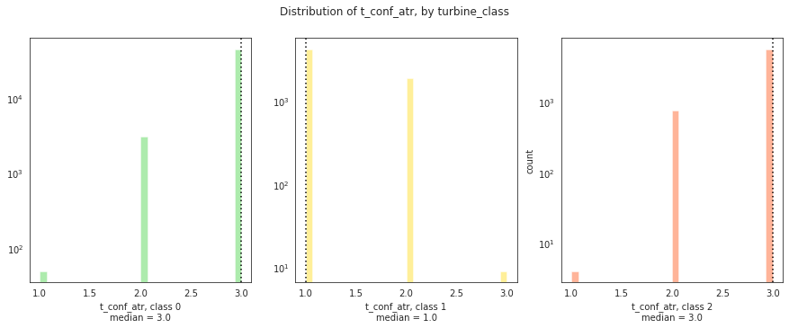

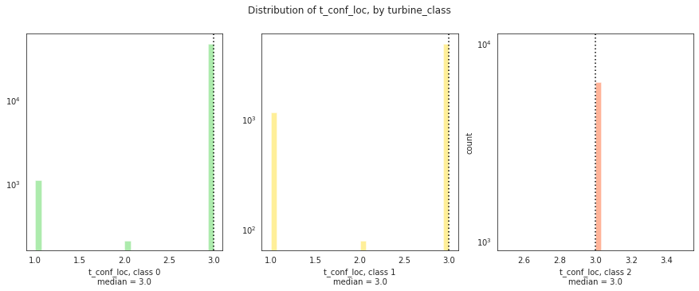

```python
for feature in cluster_columns:
    score_distribution(existing_lower48,feature)
```

### Summary of turbine_class analysis

- Class 2 has more of the older projects, with more turbines per project, but with smaller turbines that have lower output capacity.
- Class 0 has newer projects, that may be smaller, but which have larger turbines and higher output capacity. This is by far the largest class, with nearly eight times the number of turbines of the other two classes.
- Class 1's attributes are mostly unknown, but seem to fall between Class 0 and Class 2 where known.

Based on what I see here, it seems that there are not necessarily sizes or models of turbines that are better suited to a location--more that the available technology has changed over time, trending toward the larger and more powerful.

## Preprocessing datasets--adding features in batch

Now that I have a target variable for the supervised learning model, I wanted to create additional features to help train it, using features from the NREL and transmission line datasets as well as the turbine data.

Processing geospatial data turned out to be *very* resource intensive. I had major memory issues dealing with the large NREL wind datasets--there is simply too much data for my poor laptop to handle.

[figure not shown]

I ended up writing three scripts:

### nrel_add_state_and_centroid.py

The main task this preprocessing script performs is to add features to both the turbine and NREL datasets, based on either the location of a given turbine, or the centroid of each cell in the NREL data. Separate files are written for each state.

### turbines_add_attributes.py, nrel_add_attributes.py

This script and its NREL counterpart add features to the turbines and NREL datasets for each state. Similar features are added to both datasets:

- The identity of, and distance to, the nearest transmission line from either a turbine's location, or the centroid of an NREL cell
- The number of transmission lines within 1 degree latitude/longitude of the point (turbine/centroid)
- The NREL wind_class from the dataset with exclusions
- (NREL dataset) the number of turbines within a given cell

Some cross-pollination takes place--turbine attributes (example: the number of turbines per cell) are added to the NREL dataset, and an NREL wind_class is added to the turbines dataset, based on the lowest wind_class for a given turbine's location.

### Some features added to the NREL and turbine datasets

#### Distance to the nearest transmission line

The distance from a point to the closest transmission line was calculated using a unary union of the entire transmission line dataset for a given state--so, multiple lines were combined into a single MultiLinestring object.

The point is either the centroid of an NREL cell, or a turbine, depending on the script and the datasets the script is processing.

#### Attributes of the closest transmission line

Once the closest point on the closest line is established, a second operation is performed to identify the line intersecting this point, so some of this line's attributes can be copied to the NREL or turbine dataset. This was the best way I could find to calculate not just the distance *to* a line, but to find that closest line's attributes.

#### Density of transmission lines

Another feature I was able to generate from the transmission line dataset is the density of lines for a given cell of the NREL dataset.

- First, determine a reasonable distance to look for transmission lines (1 degree latitude/longitude = ~69 miles);
- See how many lines fall within that distance from each point.

#### Here's a quick demo of how the transmission line density feature is generated.

This feature is calculated using the centroid of each cell of the NREL dataset.

```python
sample_points = pd.DataFrame({'location': ['east of Las Vegas, NV','west of Pomeroy, IA'],
                                  'lat': [36.226916, 42.549746],
                                  'long': [-114.879848, -94.763612]})
g_sample_points = gpd.GeoDataFrame(sample_points,
                                         geometry=gpd.points_from_xy(sample_points['long'],
                                                                     sample_points['lat']))
g_sample_points.crs = {'init': 'epsg:4326'}
```

```python
g_sample_points
```

|  | location | lat | long | geometry |
| --- | --- | --- | --- | --- |
| 0 | east of Las Vegas, NV | 36.226916 | -114.879848 | POINT (-114.87985 36.22692) |
| 1 | west of Pomeroy, IA | 42.549746 | -94.763612 | POINT (-94.76361 42.54975) |

This block of code transforms the two points into buffers of ~69 miles. We then join the resulting buffers to the original dataset so we can identify the buffers later.

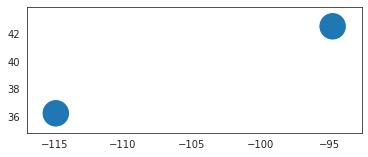

```python
g_sample_buffer = g_sample_points['geometry'].buffer(1)
g_sample_buffer.name = 'geometry'
g_sample_69mi = g_sample_points.drop('geometry',axis='columns').join(g_sample_buffer)
g_sample_69mi.plot()
```

```python
g_sample_69mi
```

|  | location | lat | long | geometry |
| --- | --- | --- | --- | --- |
| 0 | east of Las Vegas, NV | 36.226916 | -114.879848 | POLYGON ((-113.87985 36.22692, -113.88466 36.1... |
| 1 | west of Pomeroy, IA | 42.549746 | -94.763612 | POLYGON ((-93.76361 42.54975, -93.76843 42.451... |

Once buffers have been created for each point, join them to the set of high-power transmission lines to find candidates.

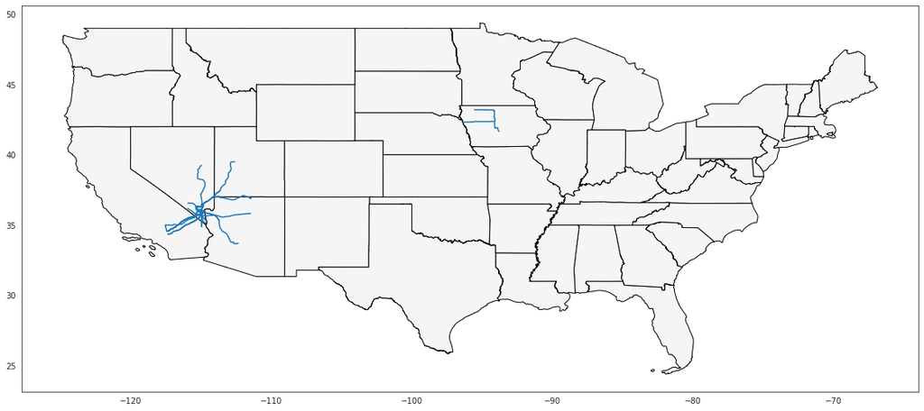

```python
fig = plt.figure()
ax = lower48_borders.plot(figsize=(20,20),color='whitesmoke',edgecolor='black')
candidate_lines.plot(ax=ax)
```

#### Density of transmission lines:

```python
candidate_lines['location'].value_counts()
```

```
east of Las Vegas, NV    107
west of Pomeroy, IA        5
Name: location, dtype: int64
```

107 high-power transmission lines within 69 miles of our point near Las Vegas is probably bad. I know this is because Hoover Dam and a solar farm are all within that 69-mile radius (not to mention the city of Las Vegas).

The 5 power lines close to our point west of Pomeroy, IA indicate a better location.

"Bad" density is likely to vary across the country--the cutoff for the weight I propose may require some spot checks and tuning to get right, and may need to be generated per area (state or region, like Midwest/West/Pacific Coast/etc.).

## Next up--use the output from the preprocessing scripts to train supervised learning models, and predict good candidate sites.

Because memory is a concern, and I already handed off feature generation to a handful of external scripts, the supervised learning model that handles the processed data, and final predictions/analysis, is contained in [a separate notebook](https://github.com/iamjeremybe/thinkful_data_science/blob/master/Final%20Capstone/Thinkful%20Final%20Capstone%20-%20Siting%20Wind%20Farms%20-%20Supervised%20Learning%20models.ipynb).